# Practical Machine Learning - Project

Sabu Varghese

Wednesday, June 03, 2015

# BACKGROUND

Sport watches are gaining popularity. These watches are wearable accelerometers that measures physical activity performed by the wearer. However, these are mere measurements does not quantify how well those activities are performed.

The goal of this project is to use data from accelerometers and predict how well certain activities are performed. This is the “classe” variable in the training data set; this variable is not provided with the testing data set. The data is collected from accelerometers on the belt, forearm, arm, and dumbell of six participants. They were asked to perform barbell lifts correctly and incorrectly in 5 different ways.

# Prediction Design Steps:

- Define your error rate
- Split data into training, testing, validation (optional)
- On the training set, pick features use cross-validation
- On the training set pick prediction function use cross-validation
- If no validation, apply 1x to test set
- If validation, apply to test set and refine and apply 1x to validation

# PROJECT TASKS

## Prepare data set

Prior to the data analysis, inspect the data for data-entry errors, missing values, Outliers, Unusual (e.g. asymmetric) distributions, Changes in variability, Clustering, Non-linear bivariate relationships and Unexpected patterns.

The training data is downloaded from https://d396qusza40orc.cloudfront.net/predmachlearn/pml-training.csv and test data is downloaded from https://d396qusza40orc.cloudfront.net/predmachlearn/pml-testing.csv. Upon analysis, it was found that Variable “problem_id” does not exist in the training dataset. Also, the classe variable is available in the training dataset but not in the testing dataset.

The training dataset will be used to build the model. And then the model will be applied to the testing dataset.

As a part of preparing data, certain columns that does not provide incremental value for analysis is removed from the training. Here is the list of variables that were removed: * X * user_name * raw_timestamp_part_1 * raw_timestamp_part_2 * cvtd_timestamp * new_window * num_window

```r
pmlTrain <- read.csv("C:/Users/varghese/Coursera/predmachlearn/pml-training.csv", header=TRUE, sep=",")
pmlTest <- read.csv("C:/Users/varghese/Coursera/predmachlearn/pml-testing.csv", header=TRUE, sep=",")

#Exclude columns that do not provide any incremental value for analysis
ExcludeCols <- c("X", "user_name", "raw_timestamp_part_1", "raw_timestamp_part_2", "cvtd_timestamp", "new_window", "num_window")
pmlTrain <- pmlTrain[, !names(pmlTrain) %in% ExcludeCols]

#Discard variables with missing values
naIndex <- sapply(pmlTrain, function(x) { any(is.na(x) | x =="") })
pmlTrain <- pmlTrain[, !naIndex]

preProcRslts <- preProcess(pmlTrain[, !names(pmlTrain) %in% c("classe")], method=c('knnImpute', 'center', 'scale'))
pmlTrain_pv <- predict(preProcRslts, pmlTrain[, !names(pmlTrain) %in% c("classe")])

#Remove zero and near-zero value variables, if exists
nzvTrain <- nearZeroVar(pmlTrain_pv, saveMetrics=TRUE)
pmlTrain_pv <- pmlTrain_pv[,nzvTrain$nzv==FALSE]

#Add classe variable back
pmlTrain_pv$classe <- pmlTrain$classe
```

Prepared dataset has the following dimension:

```r
dim(pmlTrain_pv)
```

```
## [1] 19622    53
```

## Build Model

Before building the the model, the dataset is divided into two parts using createDataPartition function - one part will be used to create the model and the other part will be used for cross validation. The random forest algorithm is used for classification and regression since this method works well with large number of variables. The resuling modelFit is shown below:

```r
#Cross Validation
#Divide training set into two parts - one for training and the other for cross validation
set.seed(1234)

cl <- makeCluster(detectCores() - 1)
registerDoParallel(cl)

ctrl <- trainControl(classProbs=TRUE, savePredictions=TRUE, allowParallel=TRUE)

partIndex <- createDataPartition(pmlTrain_pv$classe, p=0.75, list=FALSE)

trainingCV <- pmlTrain_pv[partIndex,]
testingCV <- pmlTrain_pv[-partIndex,]

#Train model with random forest; results from cross validation is used as train control method.
modelFit <- train(trainingCV$classe ~., method="rf", data=trainingCV, trControl=trainControl(method='cv'), number=5, allowParallel=TRUE )
modelFit
```

```
## Random Forest
##
## 14718 samples
##    52 predictor
##     5 classes: 'A', 'B', 'C', 'D', 'E'
##
## No pre-processing
## Resampling: Cross-Validated (10 fold)
##
## Summary of sample sizes: 13244, 13246, 13246, 13247, 13246, 13246, ...
##
## Resampling results across tuning parameters:
##
##   mtry  Accuracy   Kappa      Accuracy SD  Kappa SD
##    2    0.9926623  0.9907173  0.001717763  0.002173162
##   27    0.9923222  0.9902873  0.002848258  0.003603658
##   52    0.9891973  0.9863345  0.002907286  0.003678861
##
## Accuracy was used to select the optimal model using  the largest value.
## The final value used for the model was mtry = 2.
```

## Evaluate the Model using Cross Validation

The model was developed using the 75% of the initial dataset. This model can now be used to create confusion matrix and compare the accuracy of prediction.

```r
# Evaluate the model with the training dataset
trainingPred <- predict(modelFit, trainingCV)
confusionMatrix(trainingPred, trainingCV$classe)
```

```
## Confusion Matrix and Statistics
##
##           Reference
## Prediction    A    B    C    D    E
##          A 4185    0    0    0    0
##          B    0 2848    0    0    0
##          C    0    0 2567    0    0
##          D    0    0    0 2412    0
##          E    0    0    0    0 2706
##
## Overall Statistics
##
##                Accuracy : 1
##                  95% CI : (0.9997, 1)
##     No Information Rate : 0.2843
##     P-Value [Acc > NIR] : < 2.2e-16
##
##                   Kappa : 1
##  Mcnemar's Test P-Value : NA
##
## Statistics by Class:
##
##                      Class: A Class: B Class: C Class: D Class: E
## Sensitivity            1.0000   1.0000   1.0000   1.0000   1.0000
## Specificity            1.0000   1.0000   1.0000   1.0000   1.0000
## Pos Pred Value         1.0000   1.0000   1.0000   1.0000   1.0000
## Neg Pred Value         1.0000   1.0000   1.0000   1.0000   1.0000
## Prevalence             0.2843   0.1935   0.1744   0.1639   0.1839
## Detection Rate         0.2843   0.1935   0.1744   0.1639   0.1839
## Detection Prevalence   0.2843   0.1935   0.1744   0.1639   0.1839
## Balanced Accuracy      1.0000   1.0000   1.0000   1.0000   1.0000
```

```r
# Evaluate the model with the testing data set
testingPred <- predict(modelFit, testingCV)
confusionMatrix(testingPred, testingCV$classe)
```

```
## Confusion Matrix and Statistics
##
##           Reference
## Prediction    A    B    C    D    E
##          A 1394    4    0    0    0
##          B    1  945   15    0    0
##          C    0    0  839    9    0
##          D    0    0    1  795    0
##          E    0    0    0    0  901
##
## Overall Statistics
##
##                Accuracy : 0.9939
##                  95% CI : (0.9913, 0.9959)
##     No Information Rate : 0.2845
##     P-Value [Acc > NIR] : < 2.2e-16
##
##                   Kappa : 0.9923
##  Mcnemar's Test P-Value : NA
##
## Statistics by Class:
##
##                      Class: A Class: B Class: C Class: D Class: E
## Sensitivity            0.9993   0.9958   0.9813   0.9888   1.0000
## Specificity            0.9989   0.9960   0.9978   0.9998   1.0000
## Pos Pred Value         0.9971   0.9834   0.9894   0.9987   1.0000
## Neg Pred Value         0.9997   0.9990   0.9961   0.9978   1.0000
## Prevalence             0.2845   0.1935   0.1743   0.1639   0.1837
## Detection Rate         0.2843   0.1927   0.1711   0.1621   0.1837
## Detection Prevalence   0.2851   0.1960   0.1729   0.1623   0.1837
## Balanced Accuracy      0.9991   0.9959   0.9895   0.9943   1.0000
```

## Assess sample error

```r
varImp(modelFit)
```

```
## rf variable importance
##
##   only 20 most important variables shown (out of 52)
##
##                   Overall
## roll_belt          100.00
## yaw_belt            80.65
## magnet_dumbbell_z   65.75
## magnet_dumbbell_y   62.43
## pitch_belt          61.72
## pitch_forearm       54.33
## magnet_dumbbell_x   52.66
## roll_forearm        49.75
## accel_belt_z        43.41
## magnet_belt_z       43.10
## magnet_belt_y       42.62
## roll_dumbbell       41.99
## accel_dumbbell_y    40.98
## accel_dumbbell_z    37.40
## roll_arm            34.35
## accel_forearm_x     32.11
## accel_dumbbell_x    31.56
## yaw_dumbbell        29.73
## gyros_belt_z        29.39
## magnet_arm_y        27.68
```

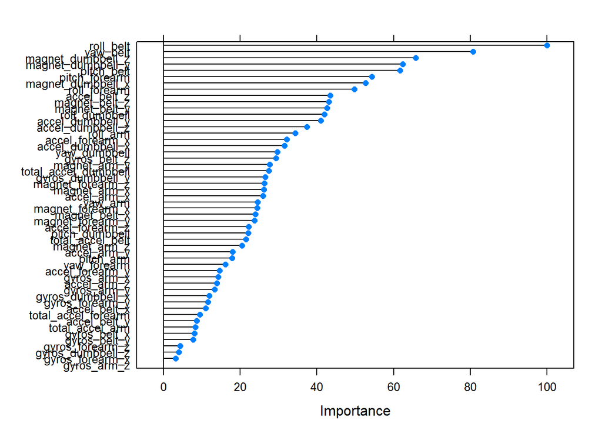

```r
plot(varImp(modelFit))
```

```r
modelFit$finalModel
```

```
##
## Call:
##  randomForest(x = x, y = y, mtry = param$mtry, number = 5, allowParallel = TRUE)
##                Type of random forest: classification
##                      Number of trees: 500
## No. of variables tried at each split: 2
##
##         OOB estimate of  error rate: 0.62%
## Confusion matrix:
##      A    B    C    D    E  class.error
## A 4183    2    0    0    0 0.0004778973
## B   15 2828    5    0    0 0.0070224719
## C    0   19 2544    4    0 0.0089598753
## D    0    0   37 2372    3 0.0165837479
## E    0    0    0    6 2700 0.0022172949
```

The sample error for the model is very low (less than 1%). This is error rate is acceptable in this setting.

## Save final model

[output not shown]

Save the final model locally for future use. The model is evaluated with a very low error rate. This can now be used to predict how well the activities are performed by the wearer.

## Apply model

Apply the finalized model to the testing dataset:

```r
pml_write_files <- function(x) {
    n = length(x)
    for(i in 1:n) {
        filename = paste0("problem_id_",i,".txt")
        write.table(x[i],file=filename,quote=FALSE,row.names=FALSE,col.names=FALSE)
    }
}

predResults <- predict(modelFit, pmlTest)
predResults
```

```
##  [1] E B B A A E E A B E B B B B E E E B E E
## Levels: A B C D E
```

```r
pml_write_files(predResults)
```

# SUMMARY